# Machine Learning Course Project: Writeup

David Cline

Thursday, November 20, 2014

This writeup documents the creation of my machine learning model to classify weightlifting activity according to its quality. I was able to build a model with the partial least squares discriminant analysis algorithm that turned out to have fairly good predictive capability.

## Reading the Data

```r
trainData <- read.csv("pml-training.csv",stringsAsFactors=FALSE)
testing <- read.csv("pml-testing.csv",stringsAsFactors=FALSE)
```

## Pre-Processing the Data

I took steps to deal with problems and inconsistencies in the dataset, attempting to move it closer to the neat and tidy ideal.

First I removed features that are not activity measurements and enforced consistent class types across both the training and test case datasets.

```r
colnames(testing)[160] <- "classe"
combinedData <- rbind(trainData,testing)
dim(combinedData)
```

```
## [1] 19642   160
```

```r
combinedData$X <- NULL
combinedData$user_name <- NULL
combinedData$raw_timestamp_part_1 <- NULL
combinedData$raw_timestamp_part_2 <- NULL
combinedData$cvtd_timestamp <- NULL
combinedData$num_window <- NULL
dim(combinedData)
```

```
## [1] 19642   154
```

```r
combinedData[,1:153] <- as.numeric(unlist(combinedData[,1:153]))
combinedData$classe <- as.factor(combinedData$classe)
```

I then removed columns with Near Zero Variance (requiring the caret package) and also those that were dominated by “NA” values reflecting missing data. This resulted in a much more tractable data environment.

```r
library(caret)
nzv <- nearZeroVar(combinedData)
filteredData <- combinedData[, -nzv]

filteredData <- filteredData[,apply(filteredData,2,
                    function(x) !any(is.na(x)))]

testing <- filteredData[19623:19642,]
trainData <- filteredData[1:19622,]
```

## Cross-Validation

I decided to use the caret package’s implentation of the partial least squares discriminant analysis (PLS) model. With the caret package loaded, cross validation procedures began with caret’s data splitting routine with randomization provided by the default bootstrap method in the createDataPartition function.

```r
set.seed(1234)
inTrain <- createDataPartition(y=trainData$classe,
                              p=0.70, list=FALSE)
training <- trainData[inTrain,]
validating <- trainData[-inTrain,]
```

Now we have three datasets: a large sample set for training the pls model, a smaller set (named “validating”) for out of sample testing, and finally the set of 20 test cases for prediction to complete the course project.

## Model Training and Tuning

Following the procedure provided by the caret package author in his recent tutorial (“A Short Introduction to the caret Package”, Max Kuhn, November 10 2014) I replaced the default bootstrap method of resampling for model tuning with K-fold cross validation and augmented number of PLS models to 35. I fitted the model and plotted the resulting accuracy.

```r
ctrl <- trainControl(method="repeatedcv",repeats=3)
set.seed(5678)
modFit <- train(classe ~ .,data=training,
        method="pls",
        tuneLength=35,
        trControl=ctrl,
        preProc = c("center", "scale"))
```

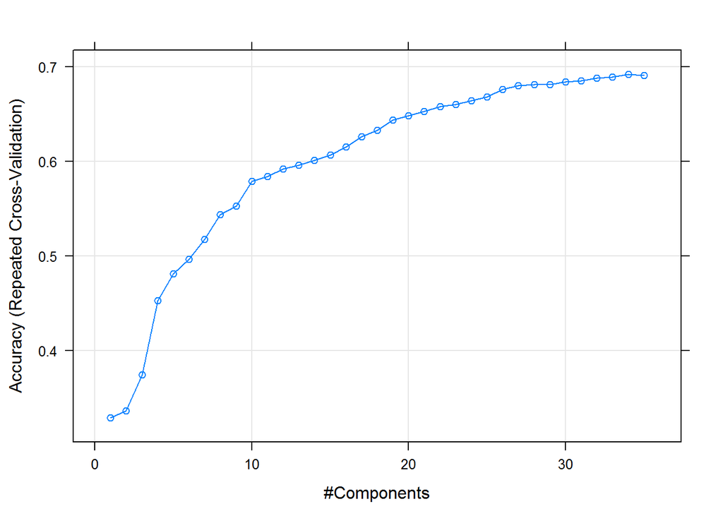

```r
plot(modFit)
```

The plot show increasing accuracy as throughout the range of 35 models but is becoming nearly asymptotic at that point, indicating little further improvement available in this model type for the dataset in its current state.

## Out of Sample Error Estimation

I predicted the quality class on the out of sample testing set (“validating”) and ran the Confusion Matrix function built into caret. This provides us with and expected accuracy of 69.1%, in a 95% Confidence Interval ranging from 67.9% to 70.3%. This forms our expectation of how well the model would predict the activity quality classes in the set of 20 test cases.

```r
modClasses <- predict(modFit,newdata=validating)
confusionMatrix(data=modClasses,validating$classe)
```

[output not shown]

[output cut: 86 more lines]

```
## Pos Pred Value             NA       NA       NA       NA       NA   0.7098
## Neg Pred Value             NA       NA       NA       NA       NA   0.9531
## Prevalence                  0        0        0        0        0   0.2845
## Detection Rate              0        0        0        0        0   0.2544
## Detection Prevalence        0        0        0        0        0   0.3584
## Balanced Accuracy          NA       NA       NA       NA       NA   0.8745
##                      Class: B Class: C Class: D Class: E
## Sensitivity            0.6198   0.5848   0.6836   0.5841
## Specificity            0.9254   0.9348   0.9293   0.9667
## Pos Pred Value         0.6660   0.6543   0.6544   0.7980
## Neg Pred Value         0.9103   0.9143   0.9375   0.9116
## Prevalence             0.1935   0.1743   0.1638   0.1839
## Detection Rate         0.1200   0.1020   0.1120   0.1074
## Detection Prevalence   0.1801   0.1558   0.1711   0.1346
## Balanced Accuracy      0.7726   0.7598   0.8064   0.7754
```